# CIS545-11 - Tech Company Employee Reviews

Camilo Riviere

14 Mar 2019

## 0.1 Introduction

The dataset I used is a compiled dataset from Kaggle (https://www.kaggle.com/petersunga/google-amazon-facebook-employee-reviews) which contains 67k employee reviews for the most prestigious tech companies in the United States, such as Google, Netflix, Amazon, Facebook, Apple, and Microsoft. The requirements of the project have requested that we provide a prescriptive analysis for our context and so I will be making a recommendation at the end of my analysis which will recommend which tech company is the best to work for based on the results of my analysis.

## 0.2 Methodology

I will be uploading the revised dataset to a local database as per the requirements of the project and I will be conducting the following topics which were covered throughout the lecture portion of CIS545-11 as well as some Exploratory Data Analysis (EDA). Below is a list of the items I will cover in this project:

## 0.3 Library Import

```r
# import "RMySQL" library for connecting to locally hosted db.
library(RMySQL)
```

```r
# import ggplot for plotting
library(ggplot2)

# %>%
library(dplyr)
```

## 0.4 Connect Data Source

```r
# establish connection to locally hosted db.
con = dbConnect(MySQL(),user = 'root', password = NULL, dbname = 'employee_review',host = '127.0.0.1',port = 3307)
```

## 0.5 Extract & Load Data

```r
# send query to retrieve all data from locally hosted db.
df = dbSendQuery(con, "SELECT * FROM employee_review")

# fetch data.
df = fetch(df, n = -1)
```

## 0.6 Data Cleaning

I have cleaned the dataset in Excel and dropped columns from the dataset which are not pertinent for the different types of Analysis that I will be performing on the dataset.

The revised content of the dataset contains the following columns:

- company
- pros
- cons
- overall-ratings
- work-balance-stars
- culture-values-stars
- career-opportunities-stars
- comp-benefit-stars
- senior-management-stars

```r
# remove id column, not necessary.
df$id = NULL
```

No other issues with dataset.

## 0.7 Exploratory Data Analysis

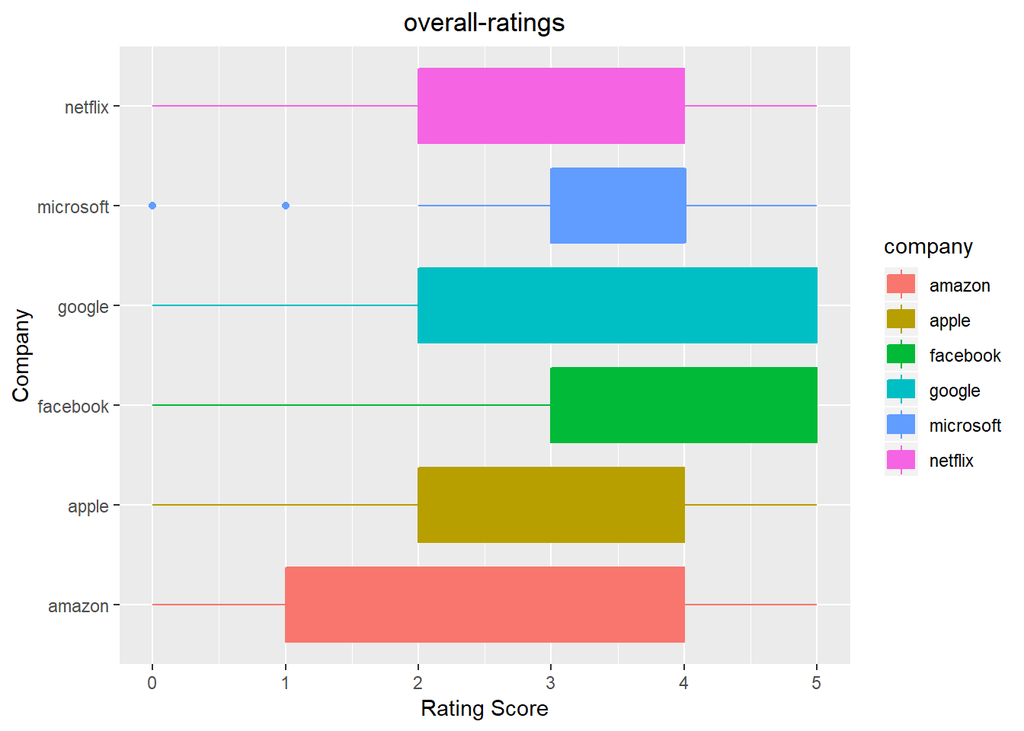

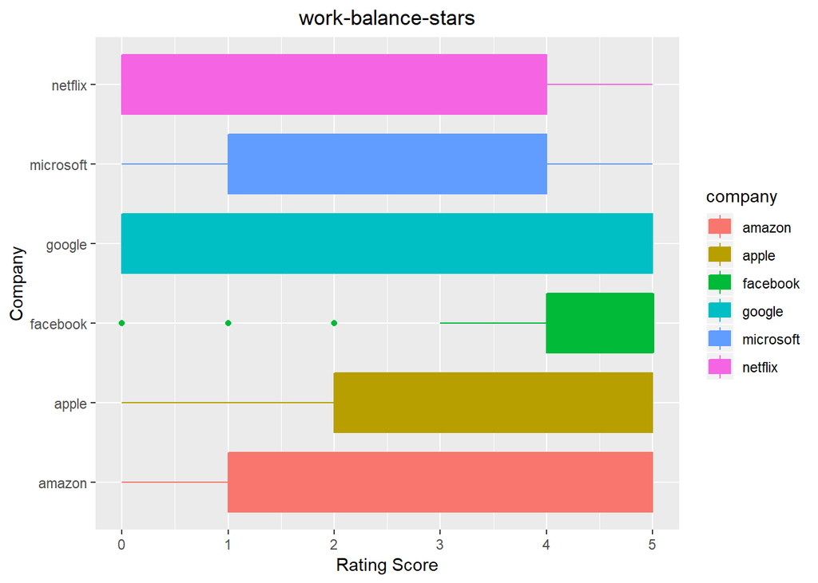

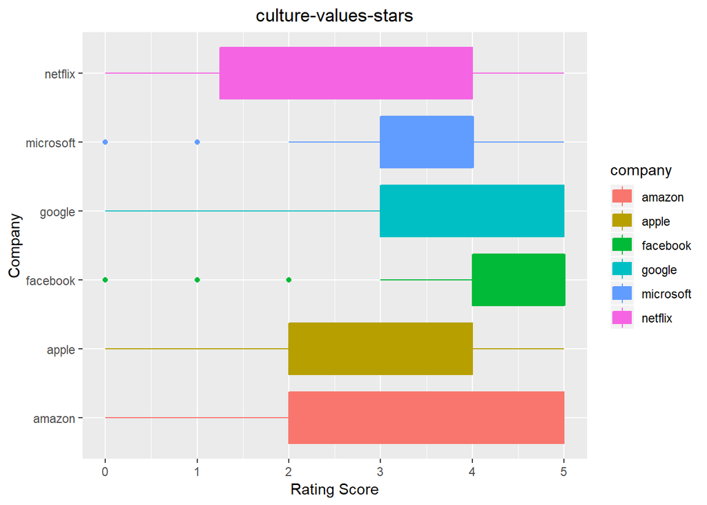

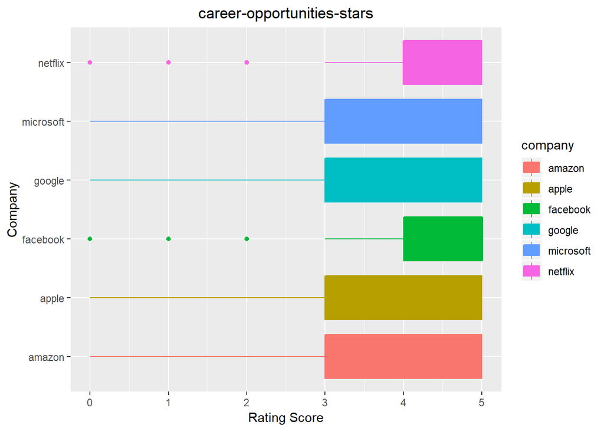

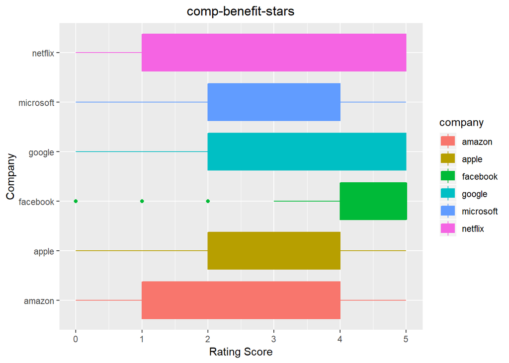

```r
# review_names var for loop
review_names = colnames(df[4:9])
index = 1

# print boxplots for each ratings grouped by companies.
for(i in df[5:9]){
   print(ggplot(df, aes(fill = company, x = company, y = i, color = company)) +
          geom_boxplot() +
          coord_flip() +
          ggtitle(review_names[index]) +
          ylab("Rating Score") +
          xlab("Company") +
          theme(plot.title = element_text(hjust = 0.5)))
          index = index + 1
}
```

```r
# initialize satisfaction column
df$Satisfaction = 0

# if ratings > mean(ratings) then employee = satisfied, else unsatisfied.
# satisfied = 1
# unsatisfied = 0
df$Satisfaction = ifelse(df$`overall-ratings` > mean(df$`overall-ratings`), 1, 0) &
                  ifelse(df$`work-balance-stars` > mean(df$`work-balance-stars`), 1, 0) &
                  ifelse(df$`culture-values-stars` > mean(df$`culture-values-stars`), 1, 0) &
                  ifelse(df$`career-opportunities-stars` > mean(df$`career-opportunities-stars`), 1, 0) &
                  ifelse(df$`comp-benefit-stars` > mean(df$`comp-benefit-stars`), 1, 0) &
                  ifelse(df$`senior-management-stars` > mean(df$`senior-management-stars`), 1, 0)

# make col type numeric
df$Satisfaction = as.numeric(df$Satisfaction)

# View num of satisfied and unsatisfied employees.
paste('Satisfied Employees', sum(df$Satisfaction[df$Satisfaction == 1]))
```

```
## [1] "Satisfied Employees 16293"
```

```r
paste('Unsatisfied Employees', length(df$Satisfaction[df$Satisfaction == 0]))
```

```
## [1] "Unsatisfied Employees 51236"
```

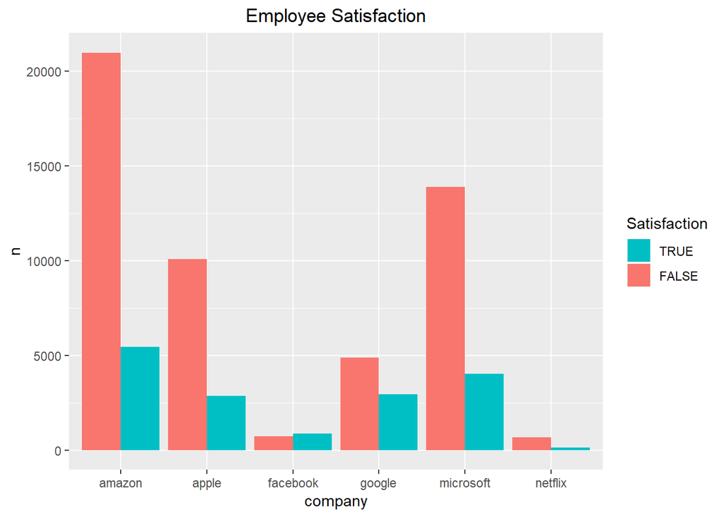

```r
# barplot - num of satisfied vs unsatisfied employees grouped by company.
bp <- df %>%
      group_by(company) %>%
      count(Satisfaction)

# convert satisfaction col to logical bool for plot.
bp$Satisfaction = as.logical(bp$Satisfaction)

print(ggplot(bp, aes(fill = Satisfaction, x = company, y = n)) +
      geom_bar(position = "dodge", stat = "identity") +
      ggtitle("Employee Satisfaction") +
      theme(plot.title = element_text(hjust = 0.5)) +
      guides(fill = guide_legend(reverse = TRUE)))
```

## 0.8 Descriptive Analysis

```r
# correlation between ratings & satisfaction.
cor(df[5:9], y = df$Satisfaction)
```

```
##                                 [,1]
## work-balance-stars         0.5300278
## culture-values-stars       0.5072506
## career-opportunities-stars 0.4868690
## comp-benefit-stars         0.4007459
## senior-management-stars    0.5130546
```

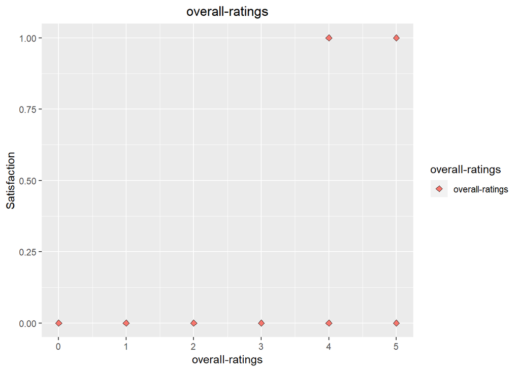

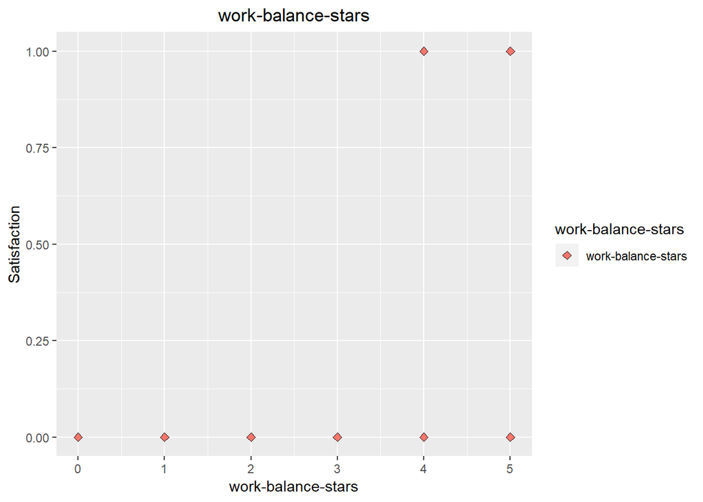

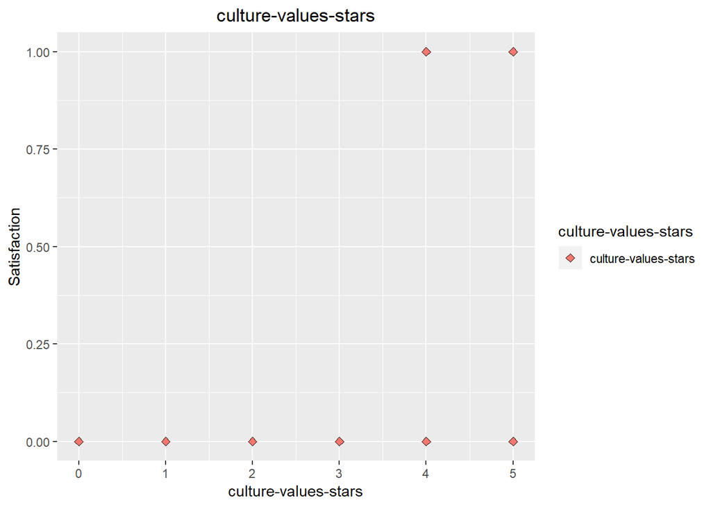

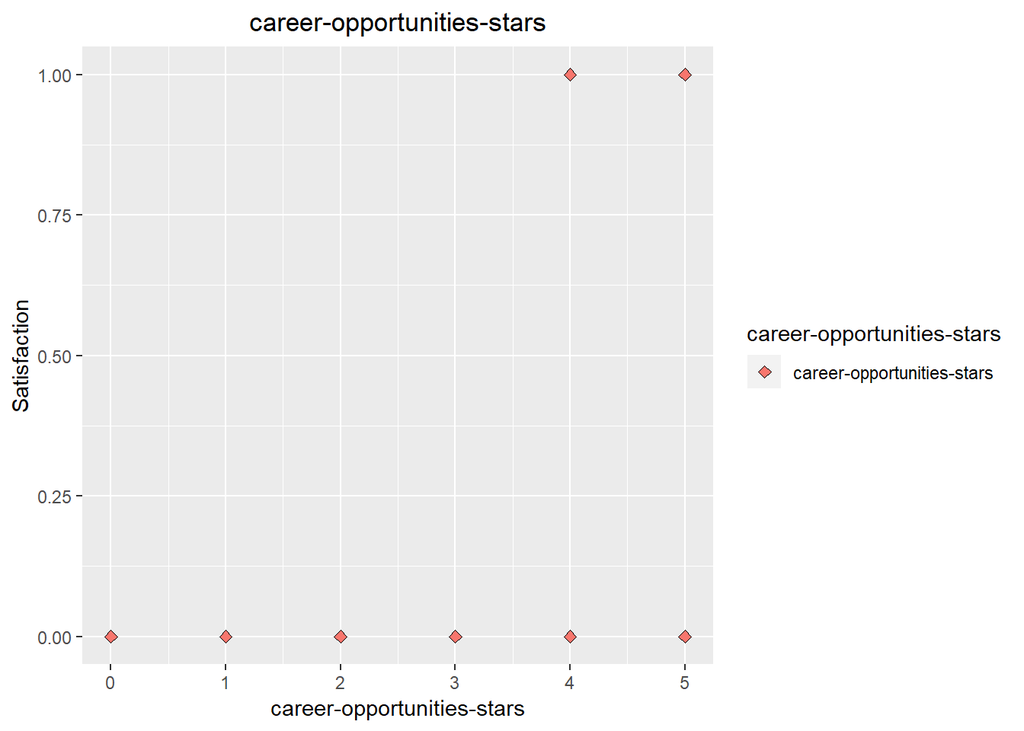

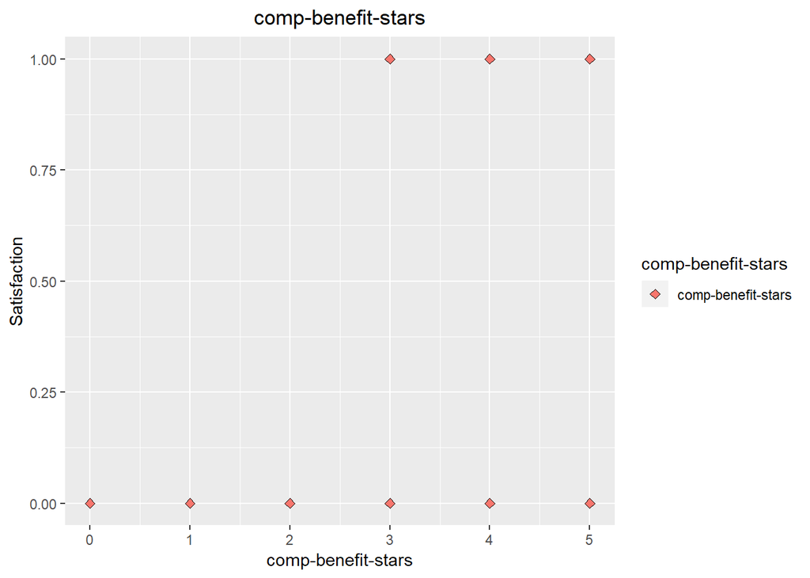

```r
# loop through & print scatterplot demonstrating relationship between rating & satisfaction.
review_names = colnames(df[4:9])
index = 1
for(i in df[5:9]){
   print(ggplot(df, aes(fill = review_names[index], i, y = df$Satisfaction)) +
    geom_point(size = 2, shape = 23) +
    ggtitle(review_names[index]) +
    xlab(review_names[index]) +
    ylab("Satisfaction") +
    theme(plot.title = element_text(hjust = 0.5)) +
    guides(fill = guide_legend(title = review_names[index])))
    index = index + 1
}
```

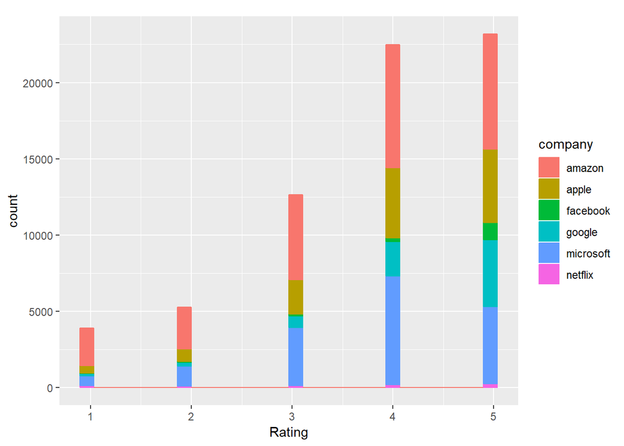

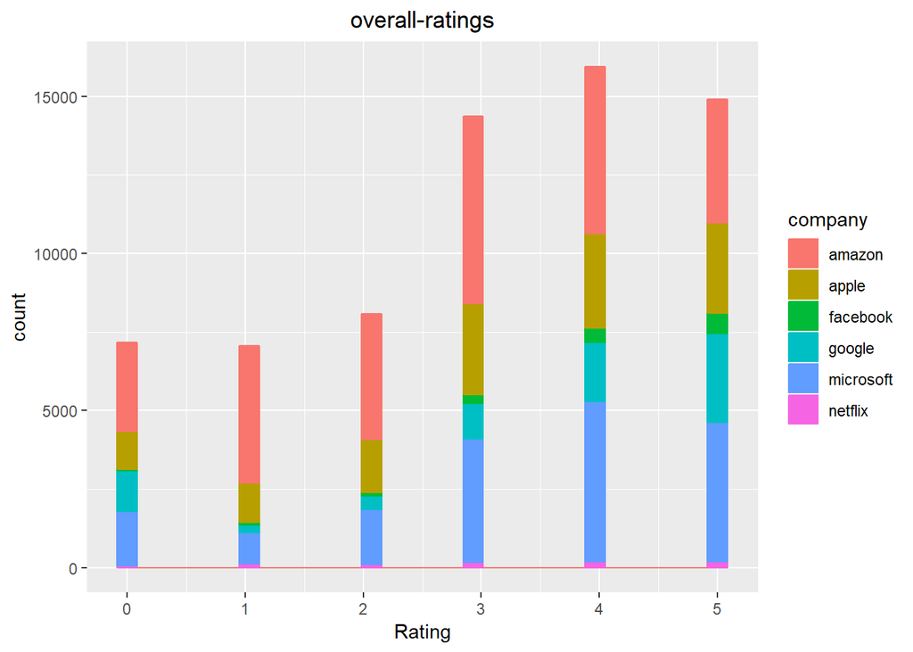

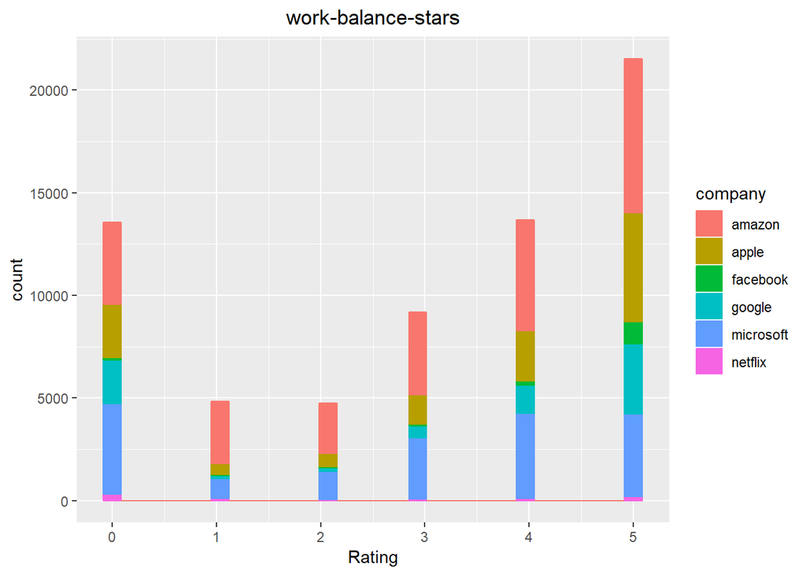

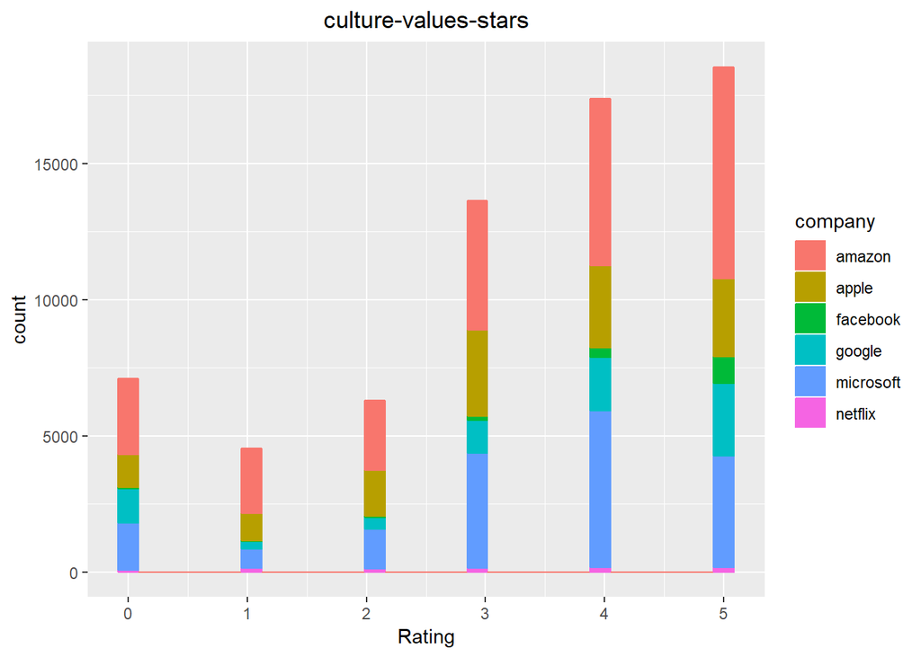

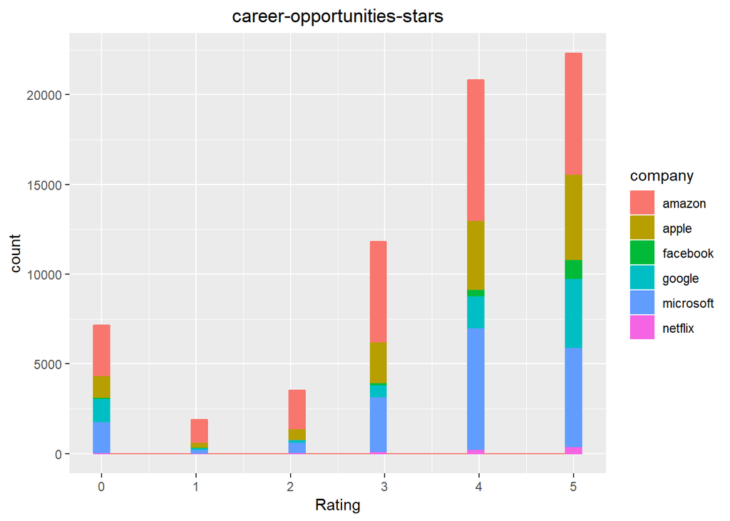

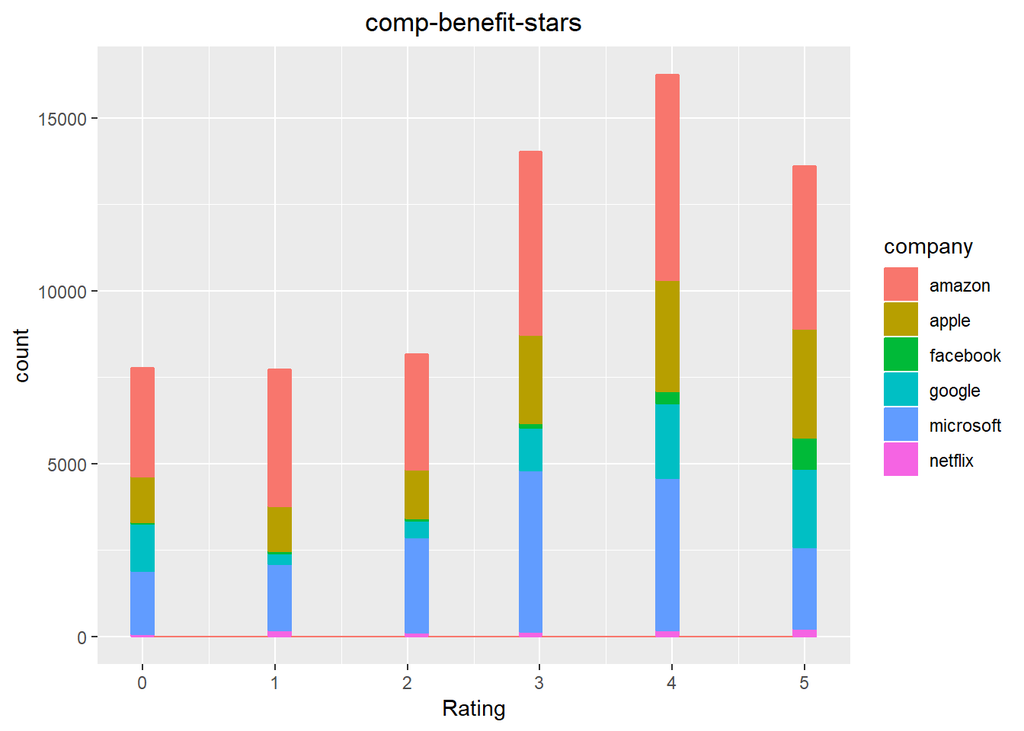

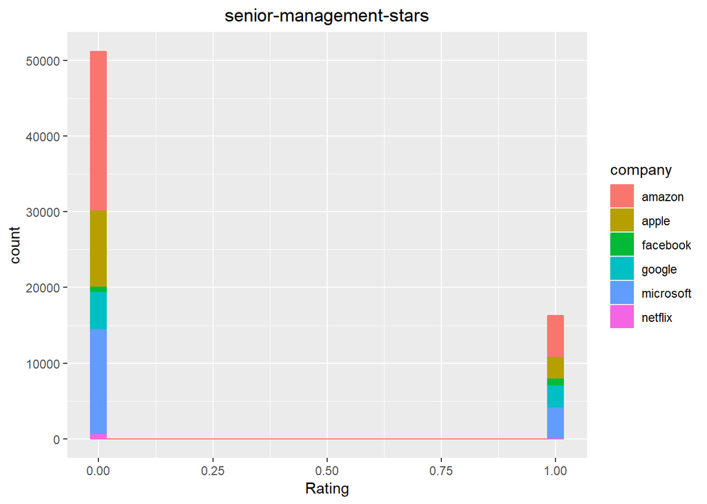

```r
# print each rating in stacked bar chart for comparison
index = 0
for(i in df[4:10]){
  print(ggplot(df, aes(fill = company, x = i, color = company)) +
          geom_histogram() +
          ggtitle(review_names[index]) +
          xlab("Rating") +
          theme(plot.title = element_text(hjust = 0.5)))
  index = index + 1
}
```

## 0.9 Data Splitting

```r
# set analysis data to necessary columns.
df1 = df[4:10]

# set seed to ensure random number generation.
set.seed(123)

# generate sample size.
smp_size = floor(0.75*nrow(df1))

# create training indexes.
train_ind = sample(seq_len(nrow(df1)), size = smp_size)

# create training set.
df1.train = df1[train_ind,]

# create test set.
df1.test = df1[-train_ind,]

# create train set for dependent var.
satisfaction.train = df1$Satisfaction[train_ind]

# create test set for dependent var.
satisfaction.test = df1$Satisfaction[-train_ind]

# view summary of training set.
summary(df1.train)
```

```
##  overall-ratings work-balance-stars culture-values-stars
##  Min.   :1.000   Min.   :0.000      Min.   :0.000
##  1st Qu.:3.000   1st Qu.:2.000      1st Qu.:1.000
##  Median :4.000   Median :3.000      Median :4.000
##  Mean   :3.828   Mean   :3.032      Mean   :3.026
##  3rd Qu.:5.000   3rd Qu.:4.000      3rd Qu.:5.000
##  Max.   :5.000   Max.   :5.000      Max.   :5.000
##  career-opportunities-stars comp-benefit-stars senior-management-stars
##  Min.   :0.000              Min.   :0.000      Min.   :0.000
##  1st Qu.:2.000              1st Qu.:3.000      1st Qu.:2.000
##  Median :4.000              Median :4.000      Median :3.000
##  Mean   :3.268              Mean   :3.547      Mean   :2.954
##  3rd Qu.:5.000              3rd Qu.:5.000      3rd Qu.:4.000
##  Max.   :5.000              Max.   :5.000      Max.   :5.000
##   Satisfaction
##  Min.   :0.0000
##  1st Qu.:0.0000
##  Median :0.0000
##  Mean   :0.2417
##  3rd Qu.:0.0000
##  Max.   :1.0000
```

```r
# view summary of test set.
summary(df1.test)
```

```
##  overall-ratings work-balance-stars culture-values-stars
##  Min.   :1.000   Min.   :0.000      Min.   :0.000
##  1st Qu.:3.000   1st Qu.:2.000      1st Qu.:1.000
##  Median :4.000   Median :3.000      Median :4.000
##  Mean   :3.821   Mean   :3.029      Mean   :3.024
##  3rd Qu.:5.000   3rd Qu.:4.000      3rd Qu.:5.000
##  Max.   :5.000   Max.   :5.000      Max.   :5.000
##  career-opportunities-stars comp-benefit-stars senior-management-stars
##  Min.   :0.000              Min.   :0.000      Min.   :0.000
##  1st Qu.:2.000              1st Qu.:3.000      1st Qu.:2.000
##  Median :4.000              Median :4.000      Median :3.000
##  Mean   :3.249              Mean   :3.529      Mean   :2.935
##  3rd Qu.:5.000              3rd Qu.:5.000      3rd Qu.:4.000
##  Max.   :5.000              Max.   :5.000      Max.   :5.000
##   Satisfaction
##  Min.   :0.0000
##  1st Qu.:0.0000
##  Median :0.0000
##  Mean   :0.2399
##  3rd Qu.:0.0000
##  Max.   :1.0000
```

## 0.10 Linear Model

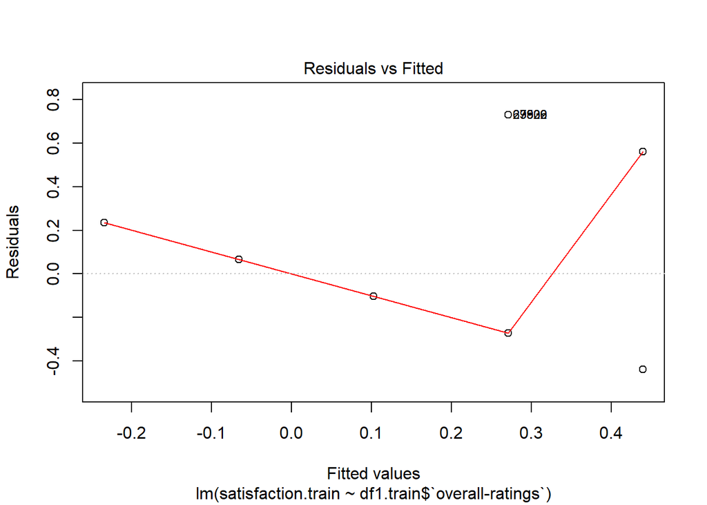

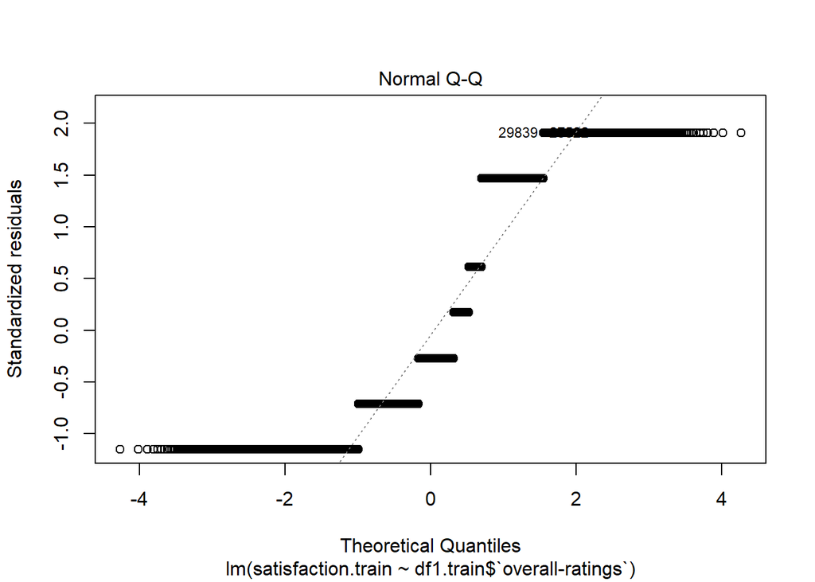

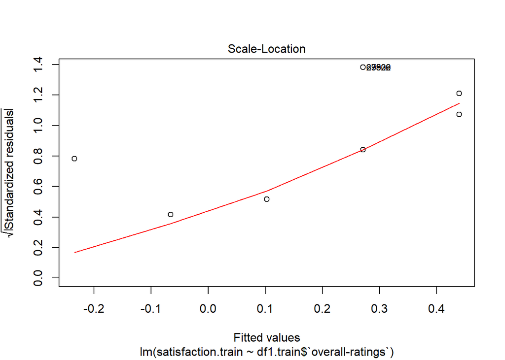

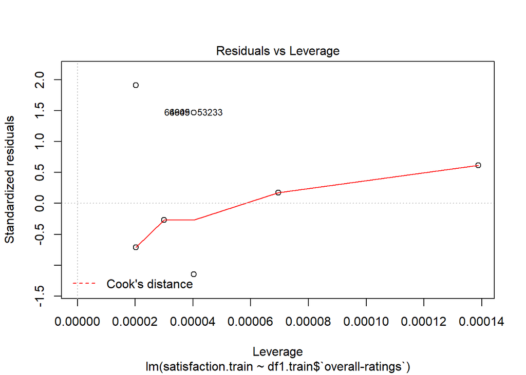

```r
# train lm model
lm.train = lm(satisfaction.train ~ df1.train$`overall-ratings`, data = df1.train)

# create pred var
y_pred = predict(lm.train, newdata = 0)

# create conf matrix (cm) to verify accuracy
cm = table(y_pred, df1.train$Satisfaction)

# print lm
print(plot(lm.train))
```

```r
# print cm
print(cm)
```

```
##
## y_pred                    0     1
##   -0.234527833929547   2872     0
##   -0.0661069147523728  3952     0
##   0.102314004424802    9601     0
##   0.270734923601976   13784  3042
##   0.439155842779151    8195  9200
```

```r
# print correct vs incorrect
print(mean(y_pred == df1.train$Satisfaction))
```

```
## [1] 0
```

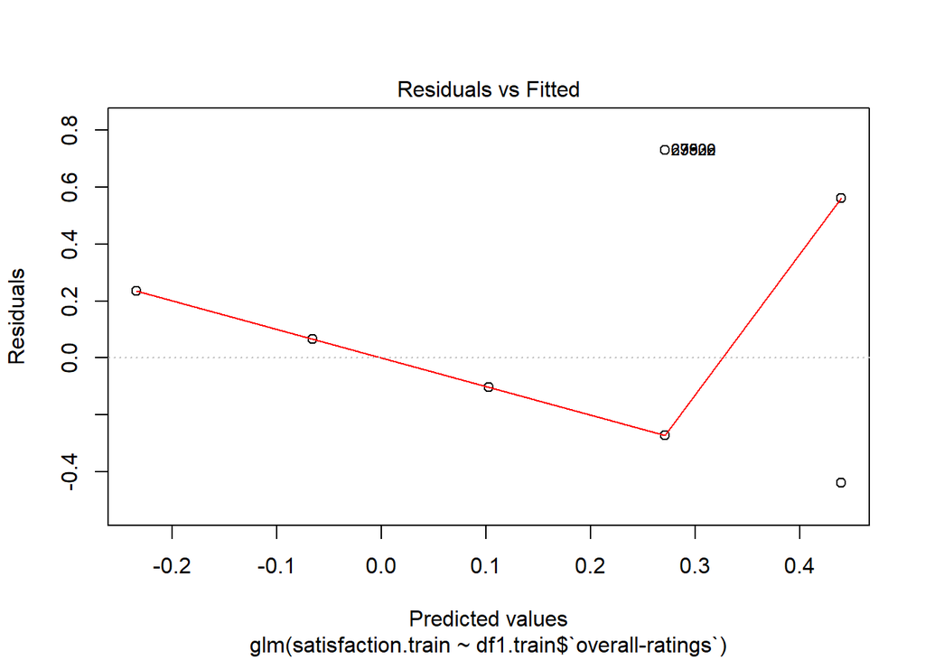

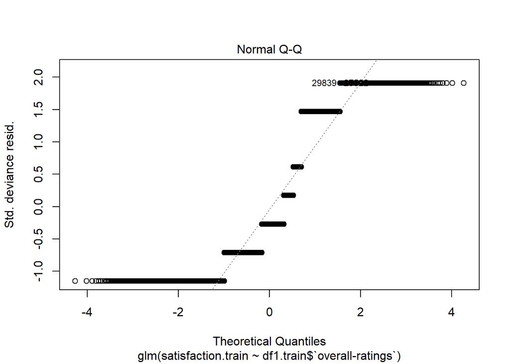

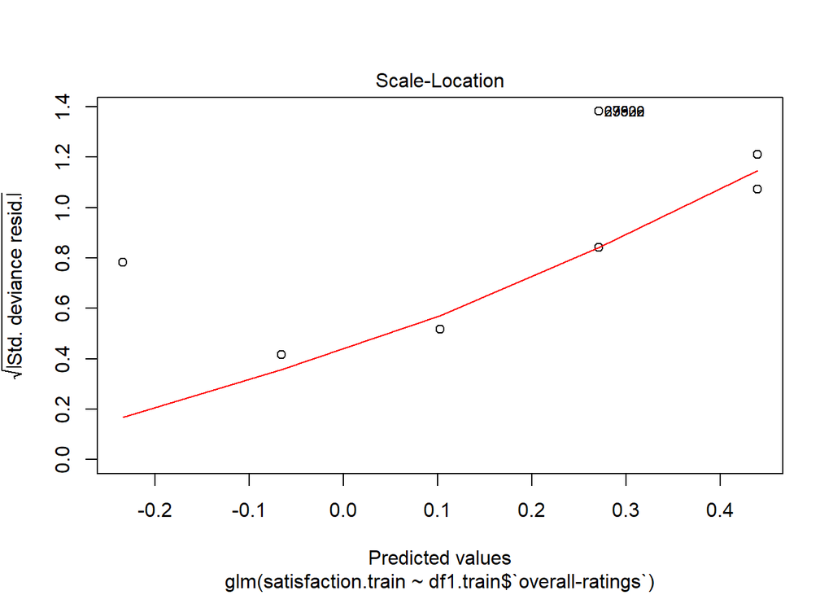

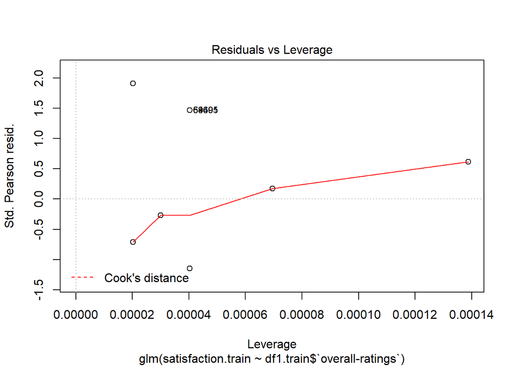

```r
# train log model
log.train = glm(satisfaction.train ~ df1.train$`overall-ratings`, data = df1.train)

# create pred var
y_pred = predict(log.train, newdata = 0)

# create conf matrix (cm) to verify accuracy
cm = table(y_pred, df1.train$Satisfaction)

# print log model
print(plot(log.train))
```

```r
# print cm
print(cm)
```

```
##
## y_pred                    0     1
##   -0.234527833929547   2872     0
##   -0.0661069147523728  3952     0
##   0.102314004424802    9601     0
##   0.270734923601976   13784  3042
##   0.439155842779151    8195  9200
```

```r
# print correct vs incorrect
print(mean(y_pred == df1.train$Satisfaction))
```

```
## [1] 0
```

## 0.12 Prescription

Based on my analysis I would recommend a prospective tech employee to work at Facebook.